# Coursera Practical Machine Learning Course Project

## Purpose

To describe the process of feature and model selection for an accurate HAR algorithm and report on it’s accuracy.

## Feature Extraction

The HAR data provided for this exercise contained 160 different features per record and were a mix of both individual and aggregated metrics. Given the grain of the test set, the aggregated features, while perhaps more useful for the classification task, could not be used. This left only the metrics that could be recorded fully on each reading.

## Feature Selection

A quick look at some of the feature plots suggests that there do exist meaningful differences in the distributions between classes for the gyros and accel measurements on the belt, arm, dumbell and forearm.

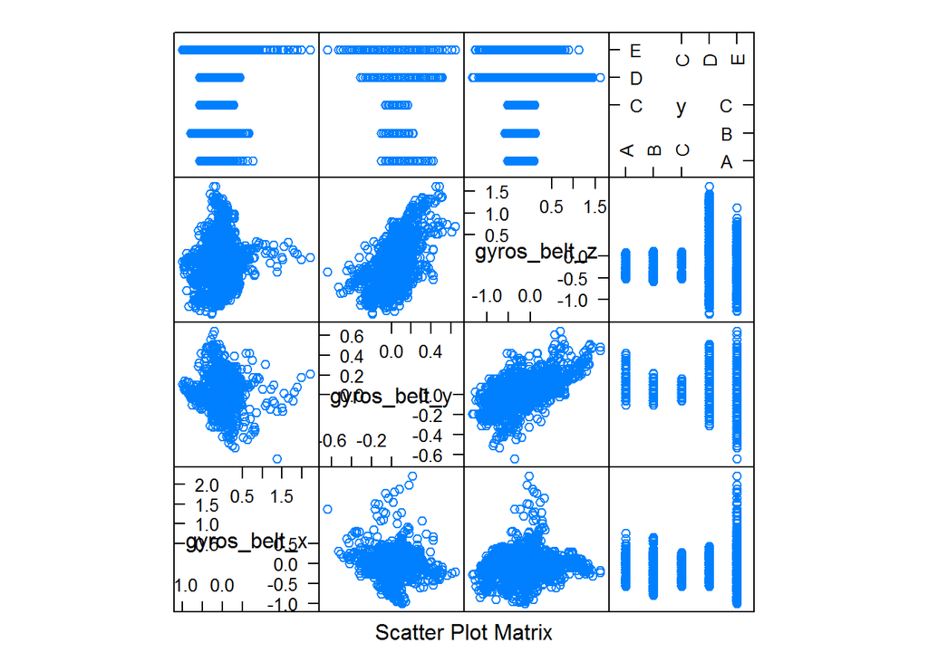

The final set of features used was: gyros_belt_x, gyros_belt_y, gyros_belt_z, accel_belt_x, accel_belt_y, accel_belt_z, gyros_arm_x, gyros_arm_y, gyros_arm_z, accel_arm_x, accel_arm_y, accel_arm_z, gyros_dumbbell_x, gyros_dumbbell_y, gyros_dumbbell_z, accel_dumbbell_x, accel_dumbbell_y, accel_dumbbell_z, gyros_forearm_x, gyros_forearm_y, gyros_forearm_z, accel_forearm_x, accel_forearm_y, accel_forearm_z

## Model Selection

```
## Random Forest
##
## 13737 samples
##    24 predictor
##     5 classes: 'A', 'B', 'C', 'D', 'E'
##
## No pre-processing
## Resampling: Bootstrapped (25 reps)
## Summary of sample sizes: 13737, 13737, 13737, 13737, 13737, 13737, ...
## Resampling results across tuning parameters:
##
##   mtry  Accuracy   Kappa
##    2    0.9664455  0.9575089
##   13    0.9529799  0.9404691
##   24    0.9346073  0.9172086
##
## Accuracy was used to select the optimal model using  the largest value.
## The final value used for the model was mtry = 2.
```

```
##
## bb.pred.rf    A    B    C    D    E
##          A 1662   21    1    5    0
##          B    1 1103   10    1    0
##          C    2   12 1013   40    7
##          D    8    1    2  916    7
##          E    1    2    0    2 1068
```

## Out of Sample Error

```
##
## bb.pred.rf    A    B    C    D    E
##          A 1662   22    1    5    0
##          B    1 1102   10    1    0
##          C    2   12 1013   40    6
##          D    8    1    2  916    7
##          E    1    2    0    2 1069
```

```
## Accuracy: [1] 0.9790994
```

```
## bb.pred.rf            A            B            C            D		E
##          A 0.9834319527 0.0130177515 0.0005917160 0.0029585799 0.0000000000
##          B 0.0008976661 0.9892280072 0.0089766607 0.0008976661 0.0000000000
##          C 0.0018639329 0.0111835974 0.9440820130 0.0372786580 0.0055917987
##          D 0.0085653105 0.0010706638 0.0021413276 0.9807280514 0.0074946467
##          E 0.0009310987 0.0018621974 0.0000000000 0.0018621974 0.9953445065
```

## Conclusion

The accuracy of the random forest method was surprisingly good given the limited information present in each sub-second observation. It seems likely that the accuracy could be even greater if larger windows of time were considered. Also accuracy could likely be further improved via implementation of an ensemble of models if the cost of additional computation is considered acceptable.